# Running an optimised trial

Nicolas Ballarini, Thomas Burnett, Thomas Jaki, Christopher Jennison, Franz Koenig, Martin Posch

2019-11-12

This vignette is an example of the trial we may run with this package. Mainly to show the `optimal1Trial` function.

We first start by defining the parameters of the trial. We will consider a trial in which the interim analysis is carried when `r = 0.3` of the patients are recruited, from a population in which `lambda = 0.5` of the patients belong to sub-group 1. For the first stage, we use a trial prevalence for subgroup 1 of `lambda.1 = 0.5` and the testing weight `w.1 = 0.5`.

We use a significance level `alpha = 0.05` and a total of `n = 700` subjects in the trial.

```r
library(OptimalTrial)
r.1      =   0.3
lambda   =   0.5
lambda.1 =   0.5
w.1      =   0.5
theta_1  =   0.3
theta_2  =   0
mu_1     =   .1
psi_1    =   sqrt(.1)
mu_2     =   0
psi_2    =   sqrt(.1)
rho0     =   .5
alpha    =   0.05
n        = 700
gamma1   = function(X_1, X_2, theta_1, theta_2, lambda, N) {lambda}
gamma2   = function(X_1, X_2, theta_1, theta_2, lambda, N) {1-lambda}
gamma12  = function(X_1, X_2, theta_1, theta_2, lambda, N) {0}
tol.zero =   0.00001
tol.lim  =   0.0001
verbose  = TRUE
use.prior.as.true = FALSE
optim_func = "hjkb"
```

We start by simulating the treatment effects estimates from the first stage.

```r
set.seed(551)
# Simulate 1st stage estimates
Sigma.1     = diag(c(4/lambda.1/n/r.1, 4/(1-lambda.1)/n/r.1))
true.mean = c(theta_1, theta_2)
theta.hat.1 = mvtnorm::rmvnorm(n = 1,
                               mean  = true.mean,
                               sigma = Sigma.1)
cat("First stage estimates are: ", theta.hat.1)
```

```
#> First stage estimates are:  0.4641509 0.04639121
```

Given First stage estimates, we now need to find the values of lambda.2 and w.2 that maximize the expected utility. We first create a grid for possible values of lambda.2 and w.2 and calculate the expected utility

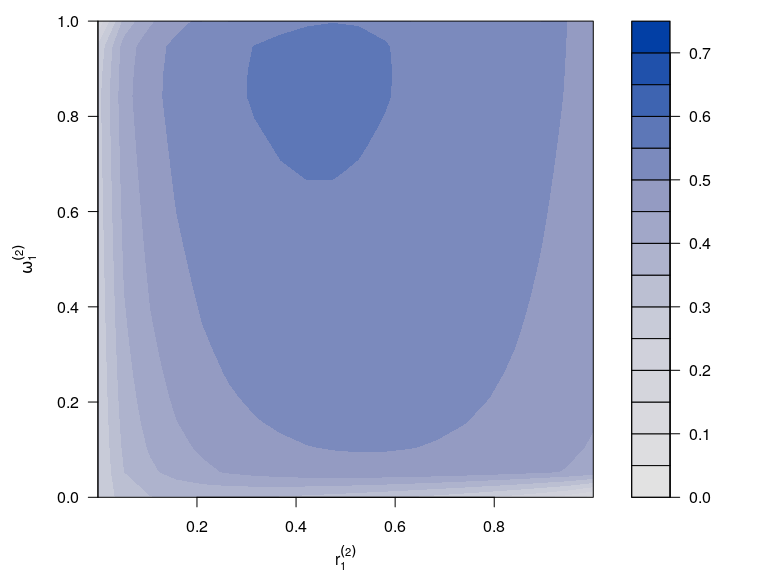

```r
lambda.2 = seq(0 + tol.lim, 1 - tol.lim, length.out = 20)
w.2      = seq(0, 1, length.out = 20)
grid  = expand.grid(lambda.2, w.2)
ngrid = length(w.2)

thetahat.1_1 = theta.hat.1[1]
thetahat.1_2 = theta.hat.1[2]

results = sapply(X = 1:nrow(grid),
                 FUN = function(x){
                    interimOptimalTrial_EU(lambda.2 = grid[x,1],
                                          w.2 = grid[x,2],
                                          x = c(thetahat.1_1, thetahat.1_2),
                                          r = r.1,
                                          rho = 0,
                                          mu_1 = mu_1, psi_1 = psi_1,
                                          mu_2 = mu_2, psi_2 = psi_2,
                                          rho0 = rho0,
                                          lambda = lambda,
                                          lambda.1 = lambda.1,
                                          n = n,
                                          w.1 = w.1, alpha=alpha,
                                          tol.zero = 1e-10,
                                          gamma1  = function(X_1, X_2, theta_1, theta_2, lambda, N) {lambda},
                                          gamma2  = function(X_1, X_2, theta_1, theta_2, lambda, N) {1-lambda},
                                          gamma12 = function(X_1, X_2, theta_1, theta_2, lambda, N) {0},
                                          verbose = FALSE)
                   })
results.df = data.frame(grid,
                        expected_utility = unlist(results[1,]),
                        case = unlist(results[2,]))
results.m = matrix(results.df$expected_utility, nrow = ngrid, ncol = ngrid)
colnames(results.m) = w.2
rownames(results.m) = lambda.2

par(mar = c(4, 5, 1, 2) + 0.1)
filled.contour(x = lambda.2, y = w.2, z = results.m,
  xlab =expression(r[1]^{(2)}), ylab = expression(omega[1]^{(2)}),
  zlim = c(0, .75),
  color.palette =  colorRampPalette(rev(colorspace::sequential_hcl(n = 4, power = 2))))
```

The `interimOptimalTrial` function performs optimization finding the value of that maximizes the expected utility directly.

```r
interimDecision = interimOptimalTrial(x = theta.hat.1,
                                      r = r.1,
                                      sigma_1 = 1, sigma_2 = 1,
                                      rho  = 0,
                                      mu_1 = mu_1, psi_1 = psi_1,
                                      mu_2 = mu_2, psi_2 = psi_1,
                                      rho0 = rho0,
                                      lambda = lambda, lambda.1 = lambda.1,
                                      n   = n,
                                      w.1 = w.1, alpha = alpha,
                                      gamma1 = gamma1,
                                      gamma2 = gamma2,
                                      gamma12 = gamma12,
                                      verbose = FALSE, optim_func = optim_func)

cat("Interim decision: lambda.2", interimDecision$par[1], "w.2", interimDecision$par[2])
```

```
#> Interim decision: lambda.2 0.4308853 w.2 0.8562775
```